# rest

Autogenerated data summary from dataMaid

2024-04-22 11:52:41.496293

# Data report overview

The dataset examined has the following dimensions:

| Feature | Result |
| --- | --- |
| Number of observations | 10000 |
| Number of variables | 16 |

### Checks performed

The following variable checks were performed, depending on the data type of each variable:

|  | character | factor | labelled | haven labelled | numeric | integer | logical | Date |
| --- | --- | --- | --- | --- | --- | --- | --- | --- |
| Identify miscoded missing values | × | × | × | × | × | × |  | × |
| Identify prefixed and suffixed whitespace | × | × | × | × |  |  |  |  |
| Identify levels with < 6 obs. | × | × | × | × |  |  |  |  |
| Identify case issues | × | × | × | × |  |  |  |  |
| Identify misclassified numeric or integer variables | × | × | × | × |  |  |  |  |
| Identify outliers |  |  |  |  | × | × |  | × |

Please note that all numerical values in the following have been rounded to 2 decimals.

# Summary table

|  | Variable class | # unique values | Missing observations | Any problems? |
| --- | --- | --- | --- | --- |
| id | character | 10000 | 0.00 % | × |
| dateAdded | character | 9455 | 0.00 % | × |
| dateUpdated | character | 9327 | 0.00 % | × |
| address | character | 9954 | 0.00 % | × |
| categories | character | 5670 | 0.00 % | × |
| primaryCategories | character | 1 | 0.00 % | × |
| city | character | 2810 | 0.00 % | × |
| country | character | 1 | 0.00 % | × |
| keys | character | 10000 | 0.00 % | × |
| latitude | numeric | 9870 | 0.00 % | × |
| longitude | numeric | 9886 | 0.00 % | × |
| name | character | 1545 | 0.00 % | × |
| postalCode | character | 5310 | 0.00 % | × |
| province | character | 47 | 0.00 % | × |
| sourceURLs | character | 10000 | 0.00 % | × |
| websites | character | 6216 | 0.00 % | × |

# Variable list

## id

- The variable is a key (distinct values for each observation).

## dateAdded

| Feature | Result |
| --- | --- |
| Variable type | character |
| Number of missing obs. | 0 (0 %) |
| Number of unique values | 9455 |
| Mode | “2017-06-19T15:23:44Z” |

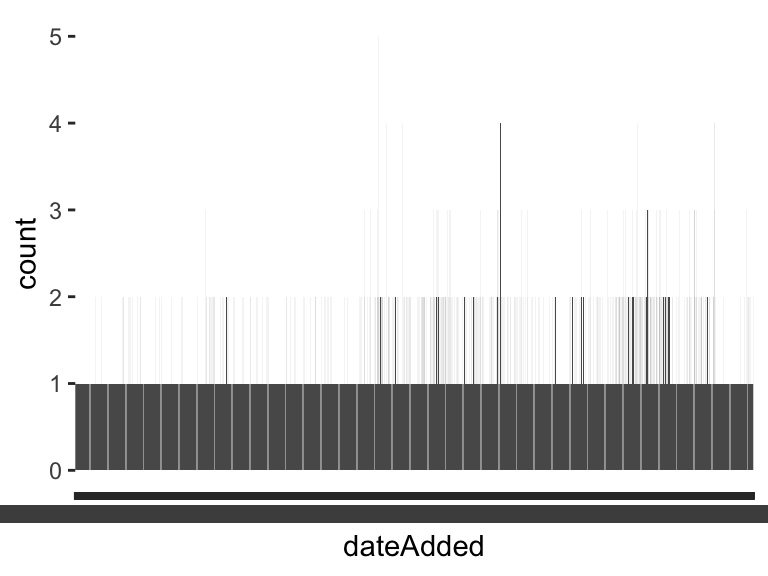

- Note that the following levels have at most five observations: "2014-01-07T05:02:14Z", "2014-02-01T04:27:16Z", "2014-02-01T04:52:02Z", "2014-02-01T05:53:47Z", "2014-02-02T04:17:42Z", …, "2019-05-19T23:24:21Z", "2019-05-19T23:24:38Z", "2019-05-19T23:26:58Z", "2019-05-19T23:45:04Z", "2019-05-19T23:58:05Z" (9445 values omitted).

## dateUpdated

| Feature | Result |
| --- | --- |
| Variable type | character |
| Number of missing obs. | 0 (0 %) |
| Number of unique values | 9327 |
| Mode | “2019-03-22T05:32:57Z” |

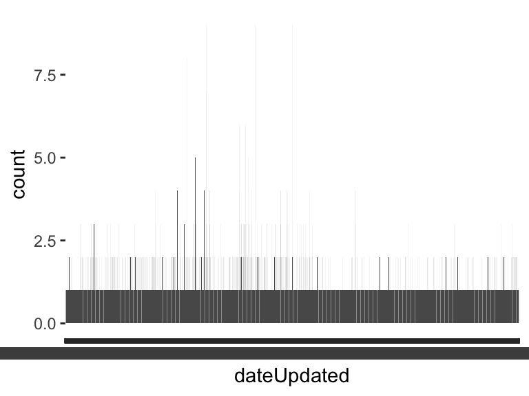

- Note that the following levels have at most five observations: "2018-12-01T00:03:40Z", "2018-12-01T07:35:22Z", "2018-12-01T07:38:03Z", "2018-12-02T00:08:36Z", "2018-12-03T09:04:19Z", …, "2019-05-19T23:24:38Z", "2019-05-19T23:26:58Z", "2019-05-19T23:45:04Z", "2019-05-19T23:45:05Z", "2019-05-19T23:58:05Z" (9310 values omitted).

## address

| Feature | Result |
| --- | --- |
| Variable type | character |
| Number of missing obs. | 0 (0 %) |
| Number of unique values | 9954 |
| Mode | “2005 Kalia Rd” |

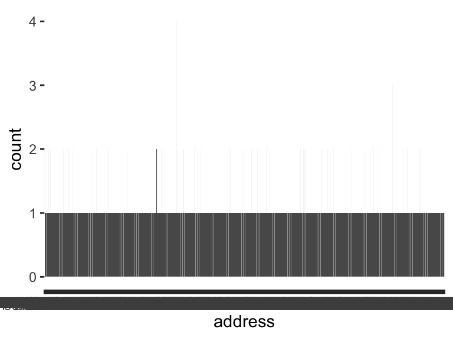

- Note that the following levels have at most five observations: "1 1st Ave SE", "1 Arnold Mall", "1 Berea Commons Ste 2", "1 Broadway Street", "1 Cedar Point Drive", …, "999 Beards Hill Road", "999 Hawthorne Ave", "9990 Harrison Ave", "9998 N Newport Hwy", "9999 Pulaski Hwy" (9944 values omitted).
- Note that there might be case problems with the following levels: "101 S Mcculloch Blvd", "101 S McCulloch Blvd", "1241 Point Mallard Pkwy Se", "1241 Point Mallard Pkwy SE", "1637 Hawthorne Ave Ne", …, "1873 Niles Cortland Rd NE", "2000 Us Highway 278 E", "2000 US Highway 278 E", "2400 6th Ave Se", "2400 6th Ave SE" (2 values omitted).

## categories

| Feature | Result |
| --- | --- |
| Variable type | character |
| Number of missing obs. | 0 (0 %) |
| Number of unique values | 5670 |
| Mode | “Fast Food Restaurants,Hamburgers and Hot Dogs,Restaurants” |

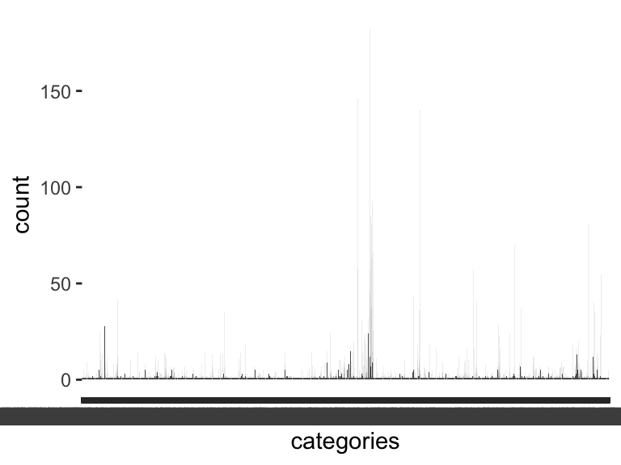

- Note that the following levels have at most five observations: "Albuquerque Restaurants,American Restaurants,Fast Food,Chicken Restaurants,Family Friendly Restaurants,Restaurants", "Alternative and complementary medicine,Carry-out food,American Restaurant,American restaurants,Fast Food Restaurants,Take Out Restaurants,Chicken Restaurants,Restaurants,Hamburgers & Hot Dogs,Burger Joint,Hot Dog Stands and Restaurants,Fast Food Restaurant,Fast Food Restaurant and American Restaurant,Alternative and complementary medicine physicians,Hyperbaric chambers and svces.,Hamburgers and Hot Dogs", "American Express,Breakfast,Visa,Carry Out,Discover,Family-Friendly Dining,Restaurants,Global,Restaurant,Food Dining,Fast Food Restaurant,Traditional American,Lunch Spot,Hamburgers,Mastercard", "American Express,Caterers,Restaurant delivery service,Food Delivery,American restaurants,Fast Food Restaurants,Visa,Home delivery beer and beverages,Carry Out,Global,Pizza Place,Barbecue,Chicken restaurants,Mastercard,Carry-out food,Karaoke,Take Out Restaurants,Food Delivery Service,Family Style Restaurants,Discover,Family-Friendly Dining,Restaurants,Pizza,Restaurant,Barbecued poultry,Food Dining,Chicken,Spare rib restaurants,Catering", "American Express,Fast Food Restaurants,Take Out Restaurants,Visa,Carry Out,Discover,Restaurants,Global,Delis And Delicatessens,Food Dining,Soups,Sandwich Shops,Mastercard", …, "Western,American Restaurants,Take-out,American,Lacto,Fast food,Ovo,Non-veg,Restaurants", "wich Place,Take Out Restaurants,Fast Food Restaurants,Restaurants,Sandwich Shops", "Wine,Carry-out food,International restaurants,Beer and Ale,Hot dog restaurants,Ice cream parlors,American restaurants,Hamburger restaurants,Fast Food Restaurants,Restaurants,Ice Cream and Frozen Desserts,Burger Joint, American Restaurant, and Restaurant,Hamburgers and Hot Dogs", "Wine,Fast Food Restaurants,Hamburgers and Hot Dogs,Restaurants", "Yogurt Manufacturers,Restaurant,Coffee Shops,Ice Cream and Frozen Desserts,Coffee and Espresso Restaurants,Fast Food Restaurants,Frozen Yogurt Shop,Dessert Restaurants,Restaurants,Ice Cream Shop" (5476 values omitted).
- Note that there might be case problems with the following levels: "American restaurants,Fast Food Restaurants,Family Style Restaurants,Restaurants", "American Restaurants,Fast Food Restaurants,Family Style Restaurants,Restaurants", "Hamburgers & Hot Dogs,Carry-out food,Hot dog restaurants,American restaurants,Hamburger restaurants,Fast food restaurants,Restaurants", "Hamburgers & Hot Dogs,Carry-out food,Hot dog restaurants,American restaurants,Hamburger restaurants,Fast Food Restaurants,Restaurants", "Hamburgers & Hot Dogs,Restaurant,Carry-out food,Hot dog restaurants,fast food restaurant,American restaurants,Hamburger restaurants,Fast Food Restaurants,Fast Food,Hamburgers and Hot Dogs,Restaurants", …, "Restaurant,Carry-out food,Hot dog restaurants,Fast Food Restaurant,Hamburger restaurants,Fast Food Restaurants,Hamburgers and Hot Dogs,Restaurants", "Restaurant,Mexican,Breakfast,Vegetarian,fast food restaurant,Fast Food,Restaurants", "Restaurant,Mexican,Breakfast,Vegetarian,Fast Food Restaurant,Fast Food,Restaurants", "Sandwich shops,Fast Food Restaurants,Restaurants", "Sandwich Shops,Fast Food Restaurants,Restaurants" (6 values omitted).

## primaryCategories

- The variable only takes one (non-missing) value: "Accommodation & Food Services". The variable contains 0 % missing observations.

## city

| Feature | Result |
| --- | --- |
| Variable type | character |
| Number of missing obs. | 0 (0 %) |
| Number of unique values | 2810 |
| Mode | “Columbus” |

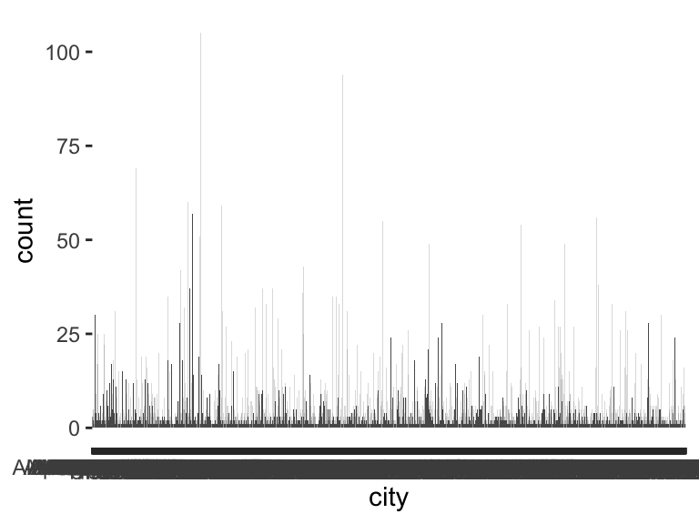

- Note that the following levels have at most five observations: "Abbeville", "Aberdeen", "Abilene", "Abingdon", "Acworth", …, "Zachary", "Zebulon", "Zelienople", "Zephyrhills", "Zion" (2394 values omitted).
- Note that there might be case problems with the following levels: "Mcminnville", "McMinnville".

## country

- The variable only takes one (non-missing) value: "US". The variable contains 0 % missing observations.

## keys

- The variable is a key (distinct values for each observation).

## latitude

| Feature | Result |
| --- | --- |
| Variable type | numeric |
| Number of missing obs. | 0 (0 %) |
| Number of unique values | 9870 |
| Median | 37.49 |
| 1st and 3rd quartiles | 33.85; 40.81 |
| Min. and max. | 19.64; 64.86 |

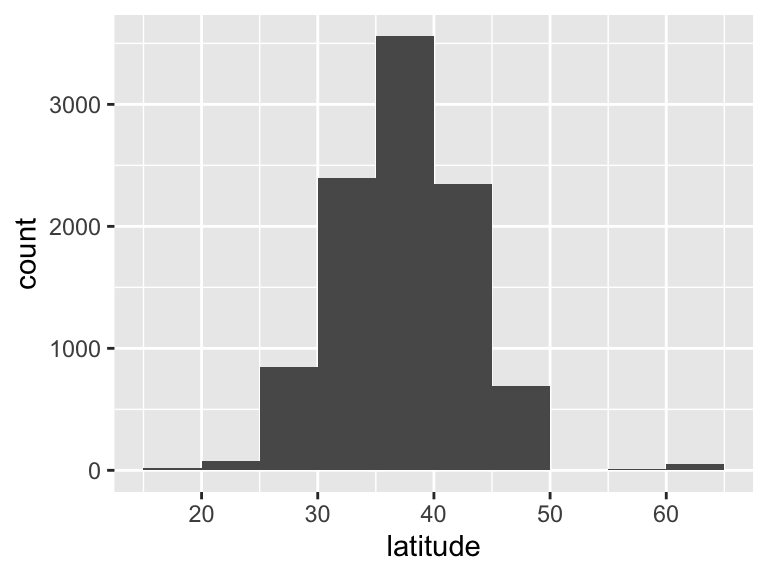

- Note that the following possible outlier values were detected: "19.64", "19.65", "19.65", "19.69", "19.7", …, "64.84", "64.85", "64.85", "64.85", "64.86" (128 values omitted).

## longitude

| Feature | Result |
| --- | --- |
| Variable type | numeric |
| Number of missing obs. | 0 (0 %) |
| Number of unique values | 9886 |
| Median | -86.68 |
| 1st and 3rd quartiles | -98.34; -81.8 |
| Min. and max. | -159.46; -71.08 |

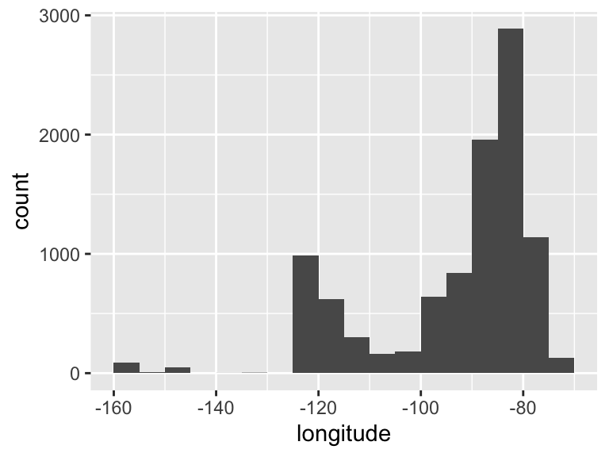

- Note that the following possible outlier values were detected: "-78.78", "-78.78", "-78.78", "-78.77", "-78.77", …, "-72.67", "-72.56", "-72.41", "-72.36", "-71.08" (874 values omitted).

## name

| Feature | Result |
| --- | --- |
| Variable type | character |
| Number of missing obs. | 0 (0 %) |
| Number of unique values | 1545 |
| Mode | “McDonald’s” |

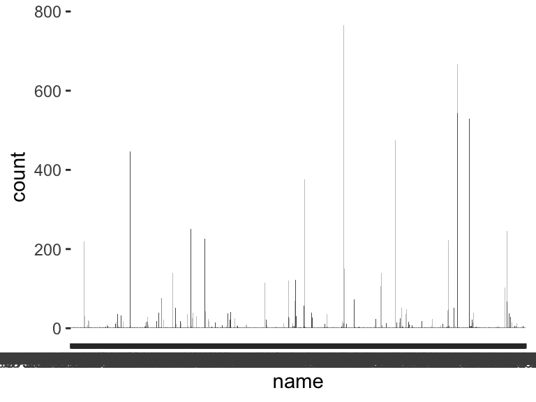

- Note that the following levels have at most five observations: "1 Frisch’s Big Boy Restaurant", "1 Gyro Shoppe", "143 Street Tacos", "2 Bits Cafe", "40 Frisch’s Big Boy Restaurant", …, "Zippy’s", "Zips It’s About Time Drive In", "Zorba’s Gyro On A Spit", "zpizza", "ZZA Pizza + Salad" (1418 values omitted).
- Note that there might be case problems with the following levels: "Albee’s Ny Gyros", "Albee’s NY Gyros", "Aw Restaurants", "AW Restaurants", "Blimpie", …, "Taco Del Mar", "Taste of Buffalo Pizzeria", "Taste Of Buffalo Pizzeria", "Wg Grinders", "WG Grinders" (40 values omitted).

## postalCode

| Feature | Result |
| --- | --- |
| Variable type | character |
| Number of missing obs. | 0 (0 %) |
| Number of unique values | 5310 |
| Mode | “37040” |

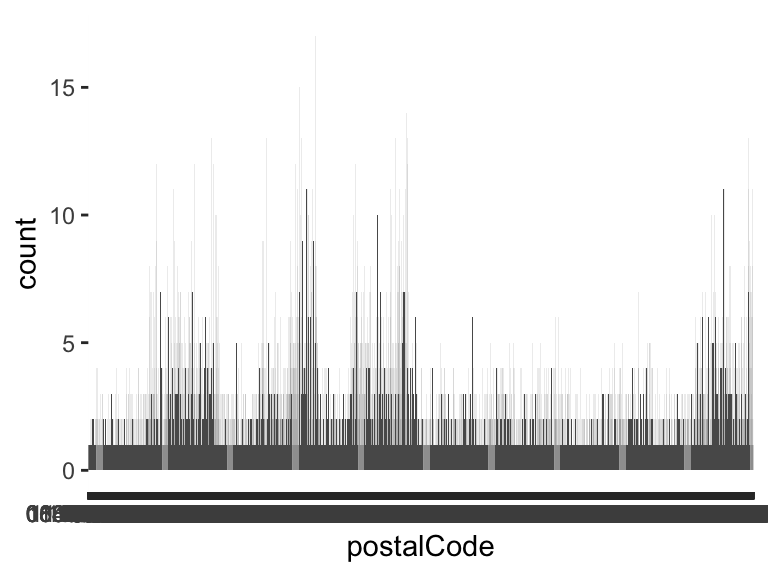

- Note that the following levels have at most five observations: "01376-1114", "01830-6104", "06450-6662", "08360-7031", "08844-5026", …, "99705", "99709", "99801", "99835", "99901" (5112 values omitted).

## province

| Feature | Result |
| --- | --- |
| Variable type | character |
| Number of missing obs. | 0 (0 %) |
| Number of unique values | 47 |
| Mode | “OH” |

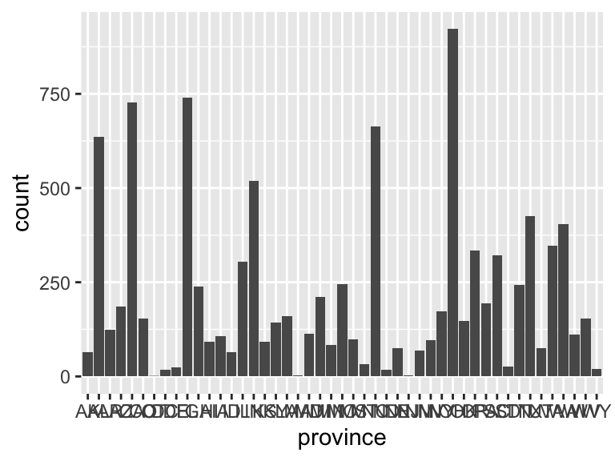

- Note that the following levels have at most five observations: "CT", "MA", "NJ".

## sourceURLs

- The variable is a key (distinct values for each observation).

## websites

| Feature | Result |
| --- | --- |
| Variable type | character |
| Number of missing obs. | 0 (0 %) |
| Number of unique values | 6216 |
| Mode | “http://www.subway.com” |

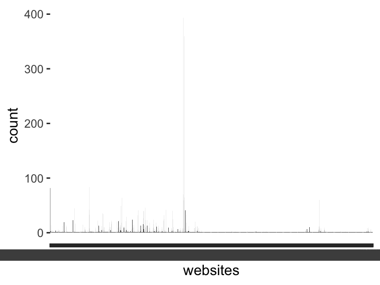

- The following suspected missing value codes enter as regular values: "".
- Note that the following levels have at most five observations: "http://570-759-1680.chinesemenu.com,http://570-759-1680.chinesemenu.com/\“, "http://716-838-1887.chinesemenu.com/\”, "http://abyssiniarestaurantandbar.com/\“, "http://ac-restaurants.com/\”, "http://adalbertosmexicanrestaurant.com/\“, …, "https://www.whataburgerofeasttexas.com/,https://www.whataburgerofeasttexas.com\”, "https://www.wingstogo.com/location/Jonesboro-AR-Parkwood-Road\“, "https://www.winstarworldcasino.com/,http://www.traditionsspirits.com/concepts/chips-n-ales\”, "https://www.zelsroastbeef.com/\“, "https://www3.hilton.com,http://www.hiltonhawaiianvillage.com/dining/tropics-bar-and-grill/,https://www3.hilton.com/\” (6053 values omitted).

Report generation information:

- Created by: Javier Castellote (username: `c32`).
- Report creation time: Mon Apr 22 2024 11:52:48
- Report was run from directory: `/Users/c32/Documents/NYCDSA/Projects/2 R Data Analysis/R Shiny - Fast Food`
- dataMaid v1.4.1 [Pkg: 2021-10-08 from CRAN (R 4.3.0)]
- R version 4.3.2 (2023-10-31).
- Platform: x86_64-apple-darwin20 (64-bit)(America/New_York).
- Function call: `makeDataReport(data = rest, output = "html", replace = TRUE)`